# TSDZPart2

## Вариант 1

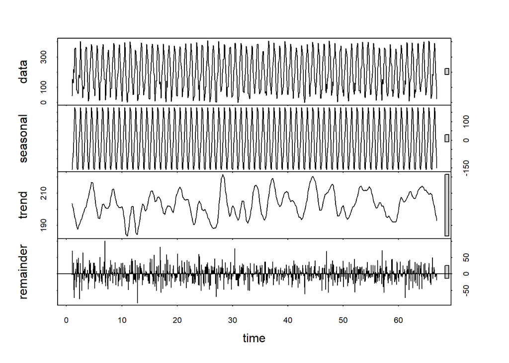

```r
stl_ <- stl(dataTS, s.window="periodic", t.window=25)
plot(stl_)
```

Нарисуем тренд на графике данные ряда

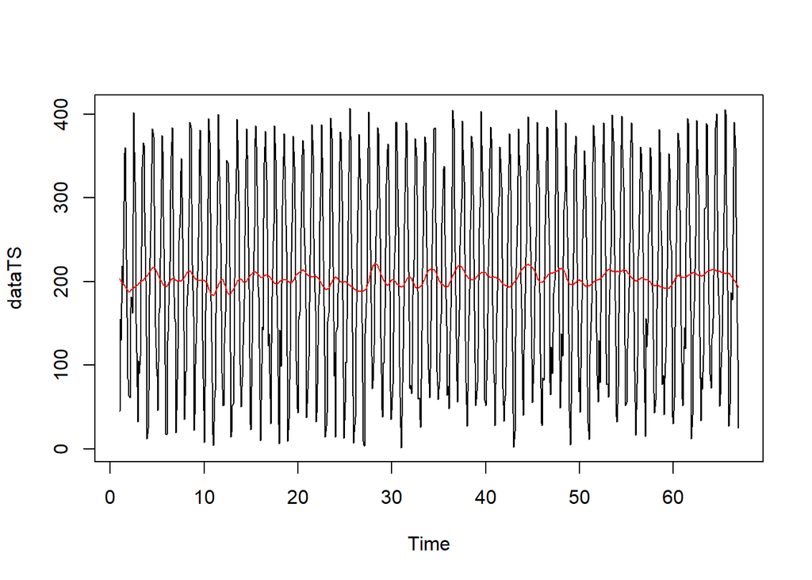

```r
plot(dataTS, col="black")
lines(stl_$time.series[,2] ,col="red")
```

График шума:

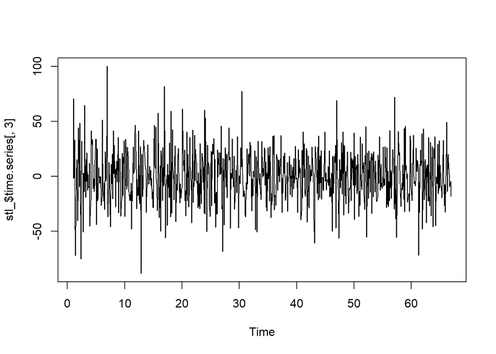

```r
plot(stl_$time.series[,3], col="black", type="l")
```

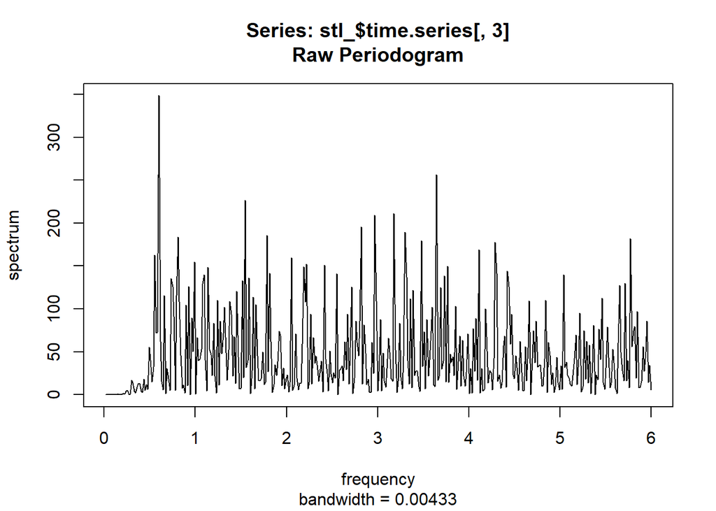

```r
SpecPGram <- spec.pgram(stl_$time.series[,3], detrend="True",  log = "no",  plot = TRUE)
```

ситуация аналогична decompose.

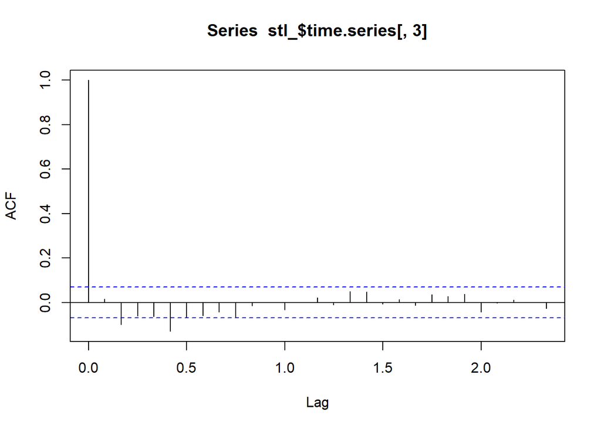

```r
acf(stl_$time.series[,3])
```

По графику автокорреляций видно, что из шума забрали низкие частоты.

## Вариант 2

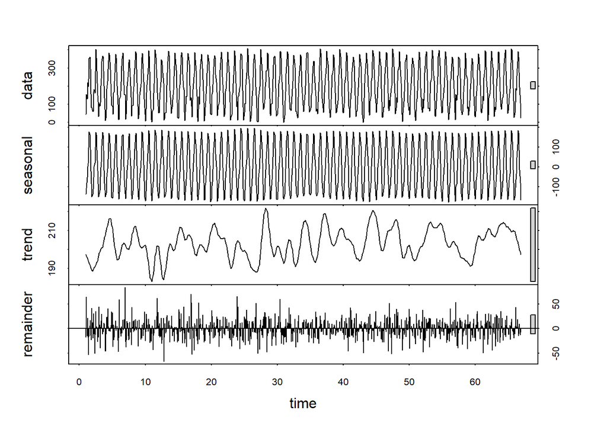

```r
stl_ <- stl(dataTS, s.window=7, t.window=25)
plot(stl_)
```

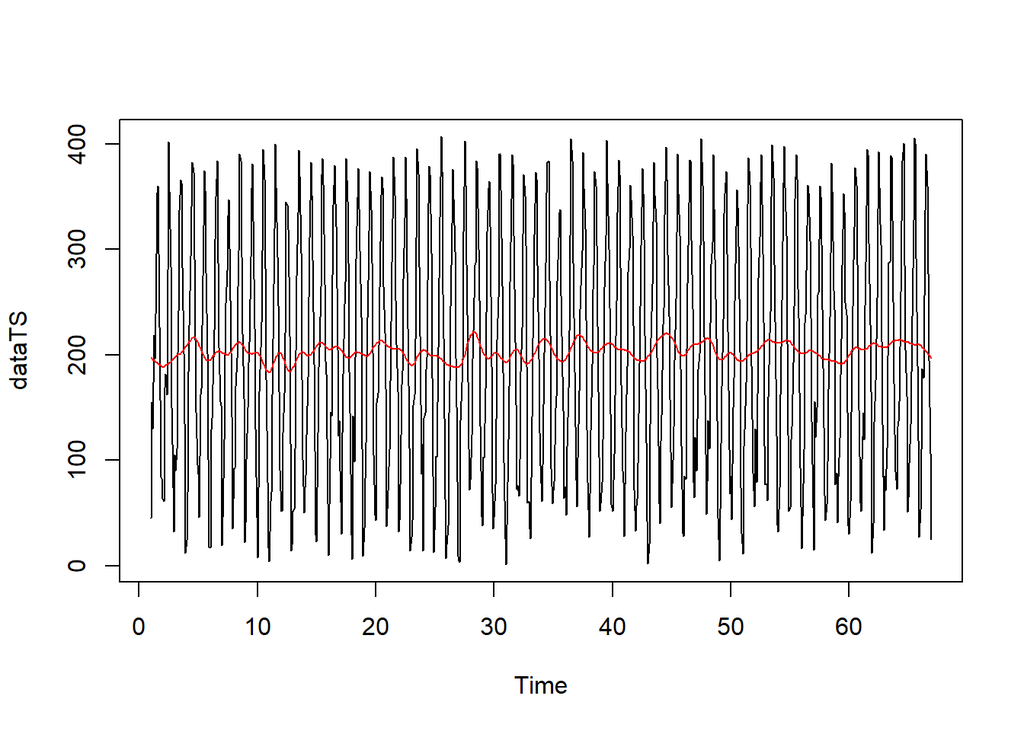

```r
plot(dataTS, col="black")
lines(stl_$time.series[,2] ,col="red")
```

График шума и периодограмма:

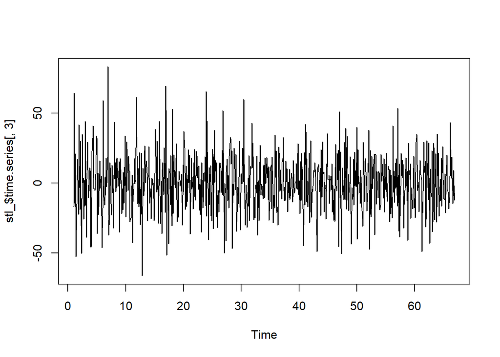

```r
plot(stl_$time.series[,3], col="black", type="l")
```

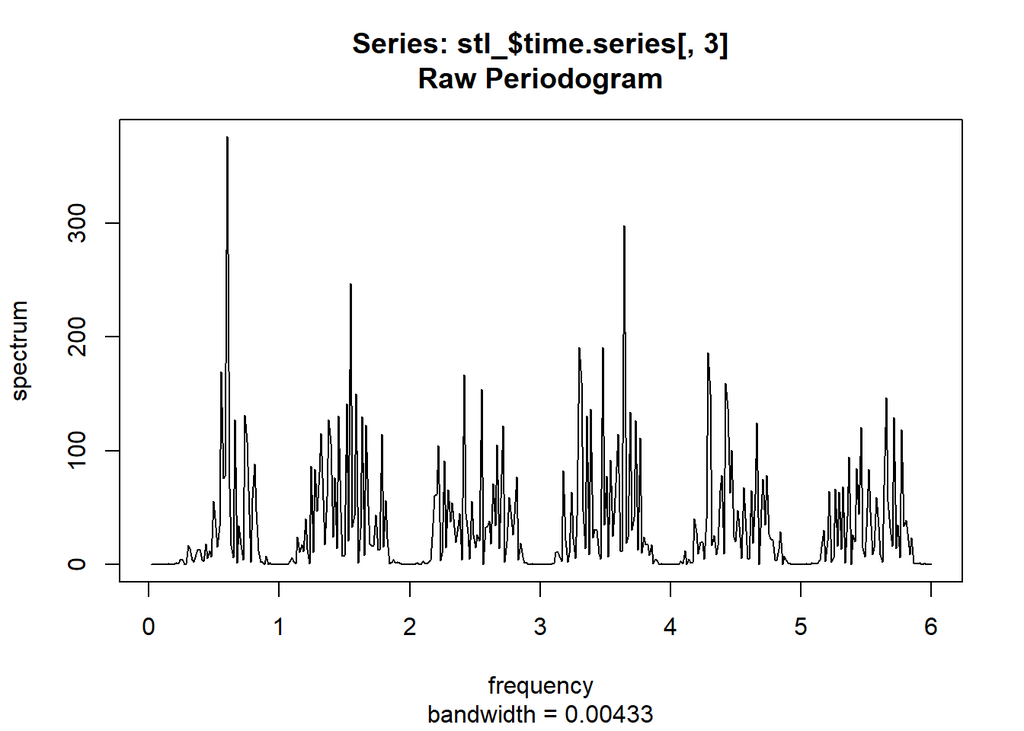

```r
SpecPGram <- spec.pgram(stl_$time.series[,3], detrend="True",  log = "no",  plot = TRUE)
```

В данной ситуации получили много вырезанных кусков из шума.

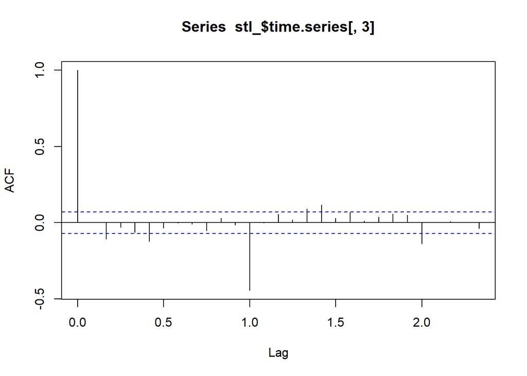

```r
acf(stl_$time.series[,3])
```

Этот вариант нам совсем не подходит.

## Вариант 3

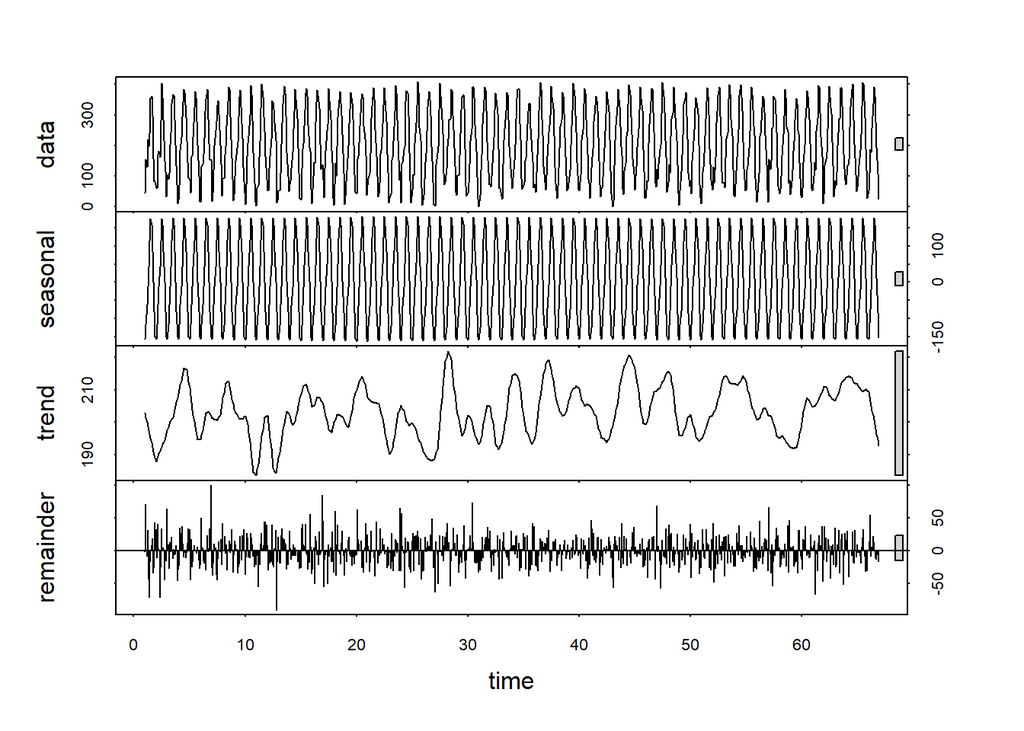

```r
stl_ <- stl(dataTS, s.window=37, t.window=25)
plot(stl_)
```

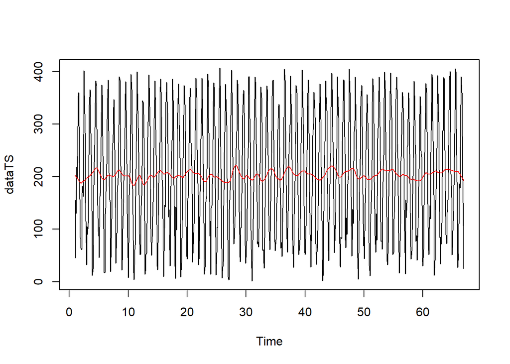

```r
plot(dataTS, col="black")
lines(stl_$time.series[,2] ,col="red")
```

График шума и периодограмма:

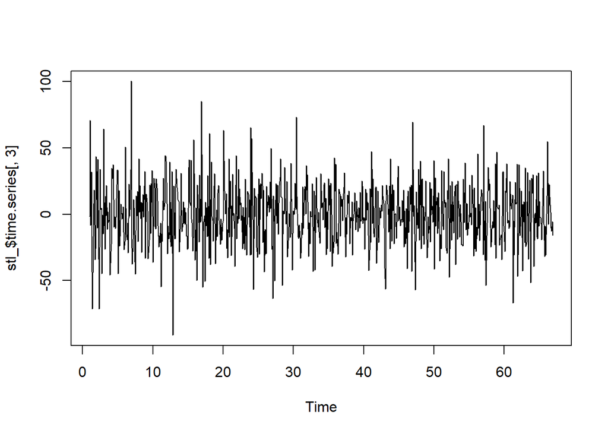

```r
plot(stl_$time.series[,3], col="black", type="l")
```

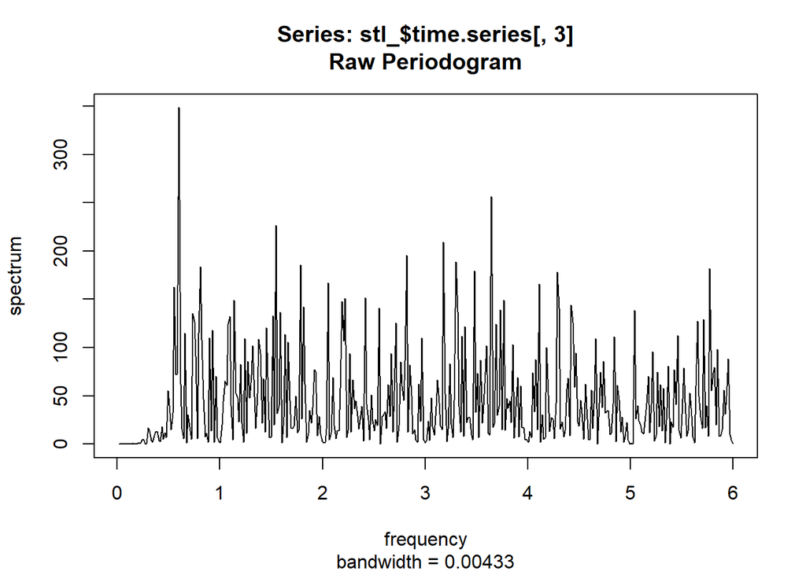

```r
SpecPGram <- spec.pgram(stl_$time.series[,3], detrend="True",  log = "no",  plot = TRUE)
```

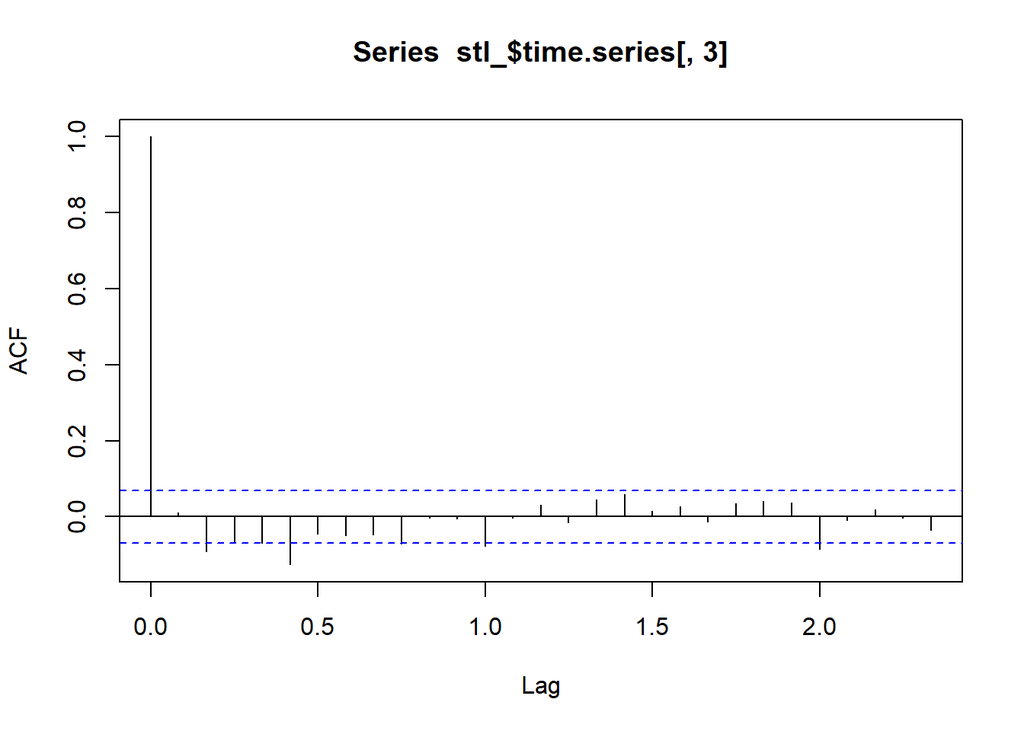

```r
acf(stl_$time.series[,3])
```

Здесь у нас ситуация аналогична варианту 1 и при увеличении параметра s.window уже далее ничего не меняется. Так что при параметрах s.window=“periodic” (сглаживание взятием среднего) можно считать мы добились лучших результатов.

# Не последоватеьный SSA

Наш тренд имеет простую форму, поэтому, нет необходимости использовать последовательный SSA. Применим SSA сразу с большой длиной окна равной половине ряда.

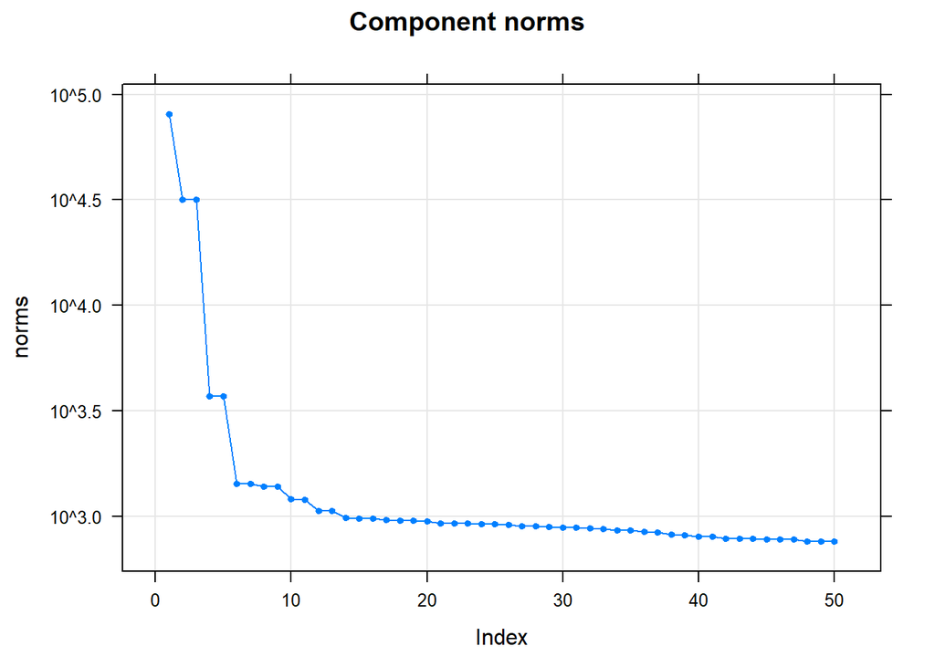

```r
s <- ssa(dataTS)
plot(s)
```

## Выделение тренда

Посмотрим на график собственных векторов:

```r
plot(s, type = "vectors")
```

[output not shown]

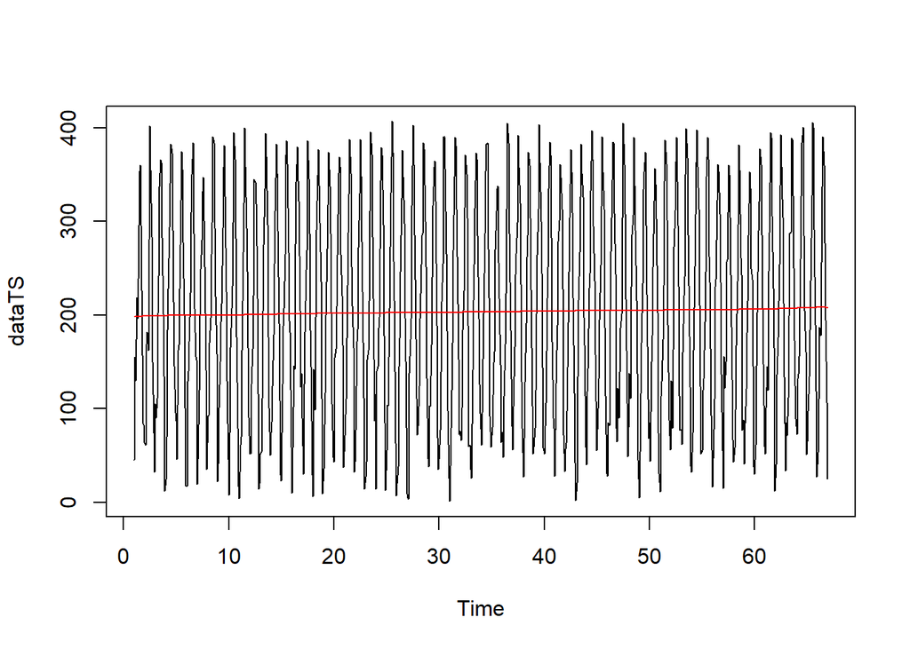

```r
rec <- reconstruct(s, groups= list(trend = c(1)))
plot(dataTS, type="l")
lines(rec$trend, col="red")
```

Теперь остаток после тренда разделим на периодическую составляющую и шум.

## ВЫДЕЛЕНИЕ ПЕРИОДИЧНОСТИ

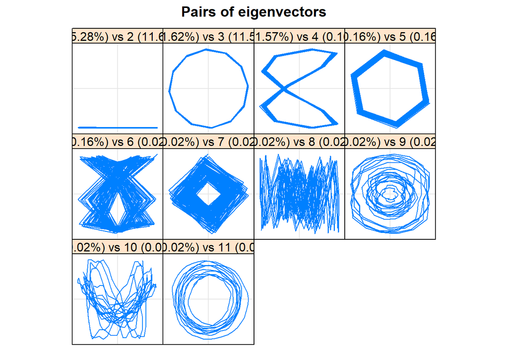

```r
plot(s, type = "paired")
```

Посмотрев на эти графики, к сезонности попробуем отнести 2:3, 4:5, 6:7 а также 10:11

```r
pe <- parestimate(s, groups = list(2:3, 4:5, 6:7, 10:11))
pe
```

```
## $F1
##    period     rate   |    Mod     Arg  |     Re        Im
##    12.001  -0.000016 |  0.99998   0.52 |  0.86604   0.49994
##   -12.001  -0.000016 |  0.99998  -0.52 |  0.86604  -0.49994
##
## $F2
##    period     rate   |    Mod     Arg  |     Re        Im
##     6.000  -0.000172 |  0.99983   1.05 |  0.49993   0.86587
##    -6.000  -0.000172 |  0.99983  -1.05 |  0.49993  -0.86587
##
## $F3
##    period     rate   |    Mod     Arg  |     Re        Im
##     4.019  -0.009989 |  0.99006   1.56 |  0.00734   0.99003
##    -4.019  -0.009989 |  0.99006  -1.56 |  0.00734  -0.99003
##
## $F4
##    period     rate   |    Mod     Arg  |     Re        Im
##    39.206  -0.000461 |  0.99954   0.16 |  0.98673   0.15950
##   -39.206  -0.000461 |  0.99954  -0.16 |  0.98673  -0.15950
```

Mатрицa w-корреляций:

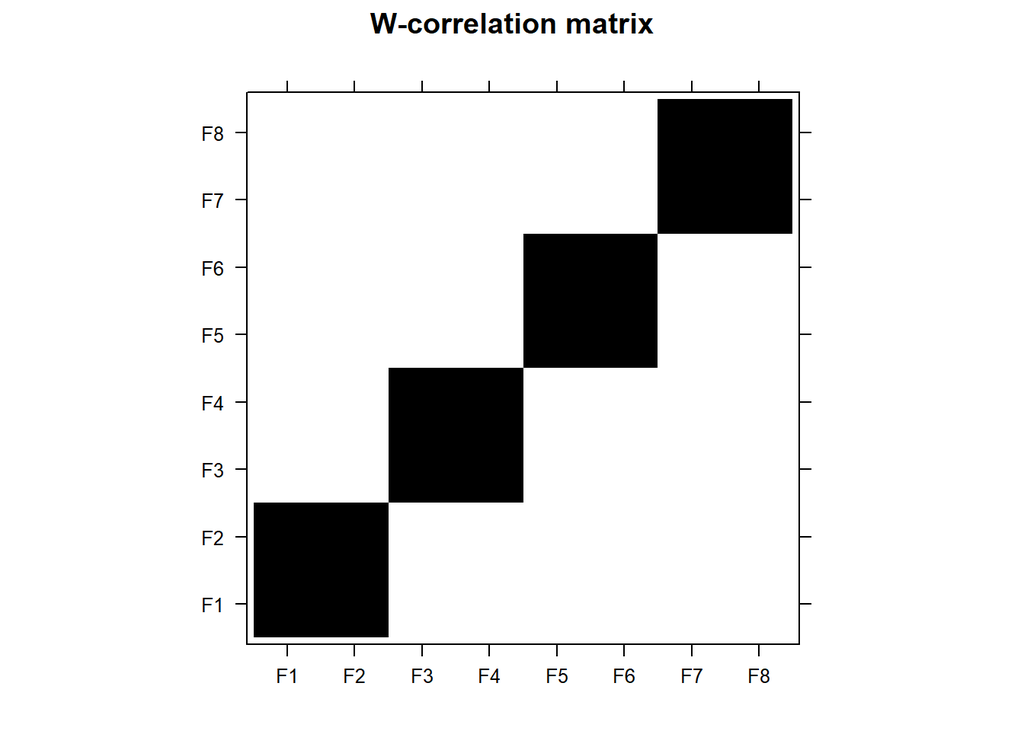

```r
sesrec <- reconstruct(s, groups = list( season = c(2:3, 4:5, 6:7, 10:11)))
plot(wcor(s, groups = c(2:3, 4:5, 6:7, 10:11)))
```

Видим, компоненты хорошо отделимы друг от друга.

Шум:

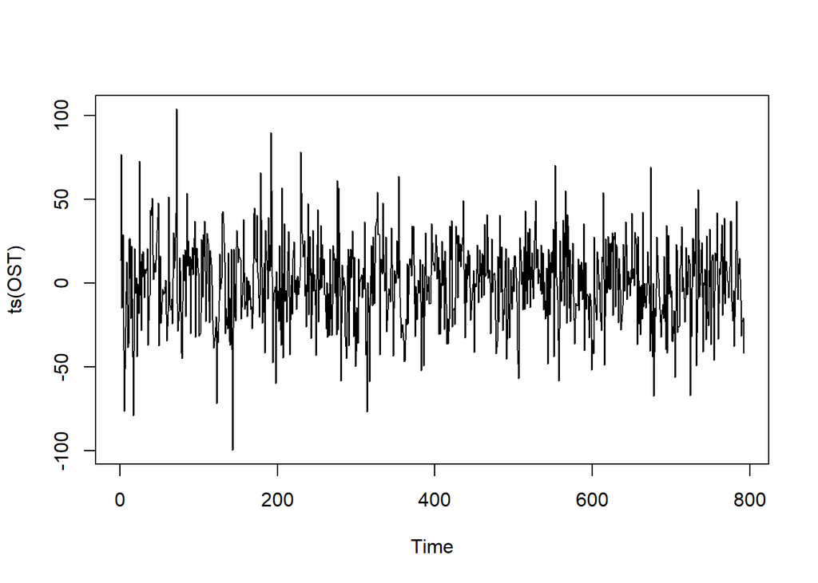

```r
OST <- dataTS - rec$trend - sesrec$season
plot(ts(OST))
```

Анализ шума:

Периодограмма остатка:

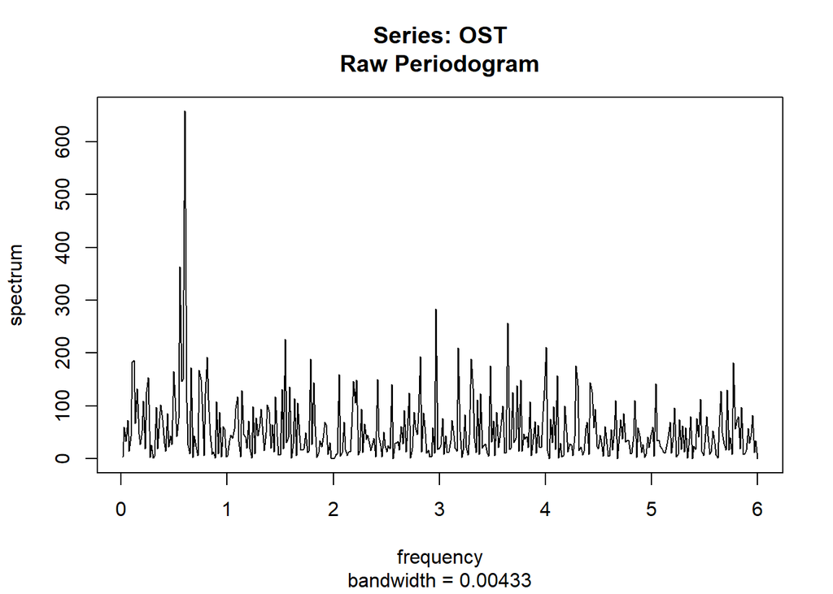

```r
spec.pgram(OST, detrend="TRUE",  log = "no",  plot = TRUE)
```

График автокорреляций:

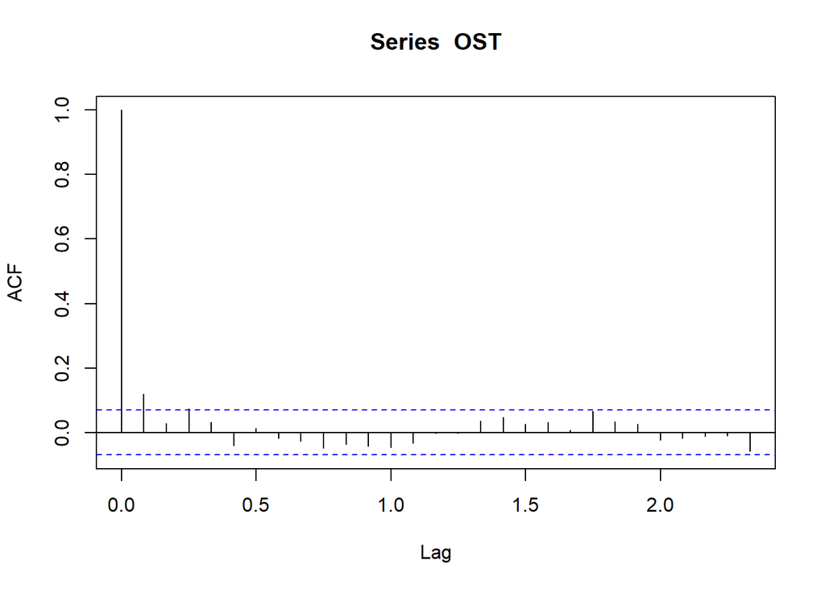

```r
acf(OST, plot = TRUE)
```

Видим в начале положительные корреляции, не белый шум.

Сравним выделенный сигнал с нашим рядом:

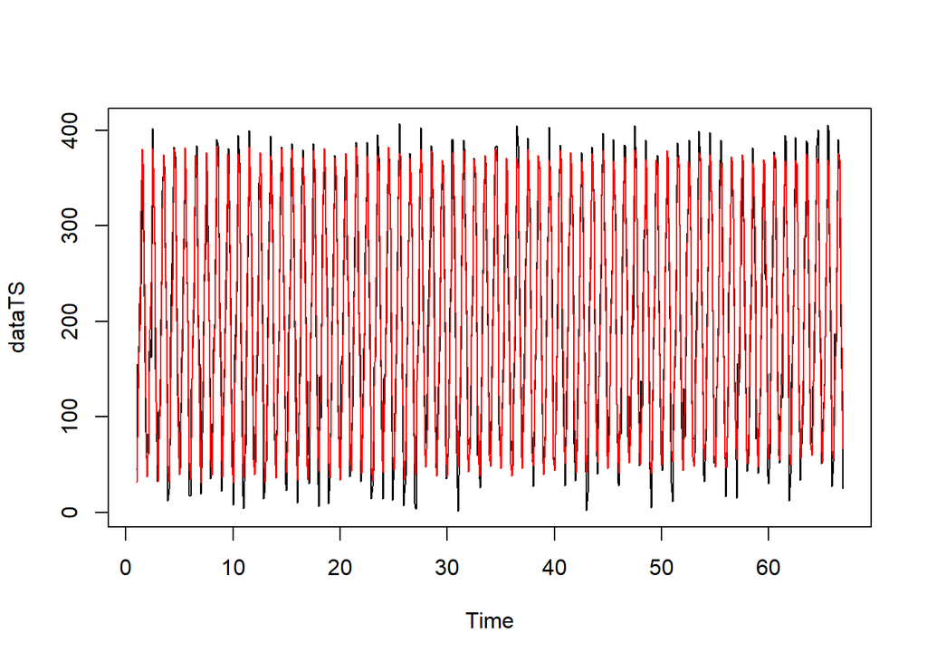

```r
TrSe <- rec$trend + sesrec$season

plot(dataTS, col="black")
lines(TrSe ,col="red")
```

У нас здесь нет проблемы со сложным трендом. Но здесь может быть проблема со сложной модуляцией синуса. Т.е. сезонность с криво меняющейся амплитудой. Сложность тренда — это сам тренд. А если сложно меняется синус, то приходится для выделения этой сезонности брать небольшое L. Cложно в каком смысле — оно локально простое, а на всем диапазоне сложное. Выход из этой ситуации — взять небольшое L для выделения сезонности.

Для этого воспользуемся последовательным SSA. Для выделения тренда будем брать длину окна равную половине ряда, а для выделения сезонности небольшую длину окна кратную периоду — 60.

# SSA Последовательный

## ТРЕНД

Для выделения тренда было приянто решение взять длину окна в половину ряда.

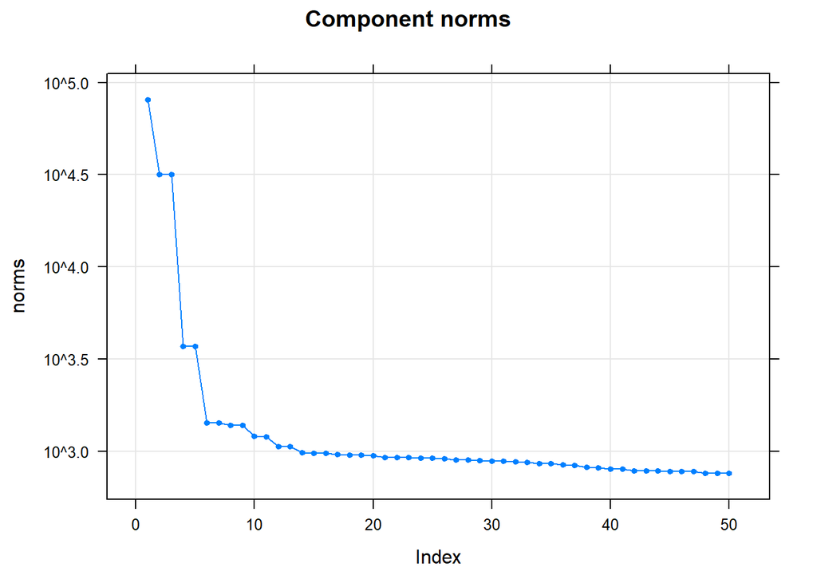

```r
s <- ssa(dataTS)
plot(s) # с.ч.
```

Далее нужно выбрать компоненты, которые будут входить в тренд. Посмотрим на графики собственных векторов:

```r
plot(s, type = "vectors")
```

[output not shown]

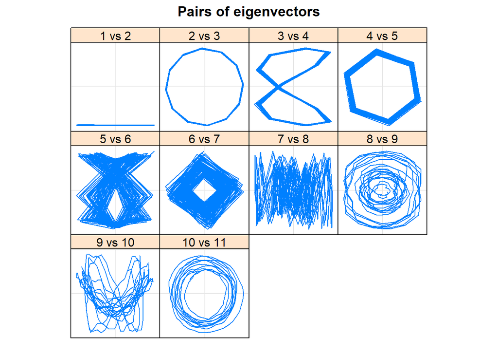

```r
plot(s, type = "paired", plot.contrib = FALSE)
```

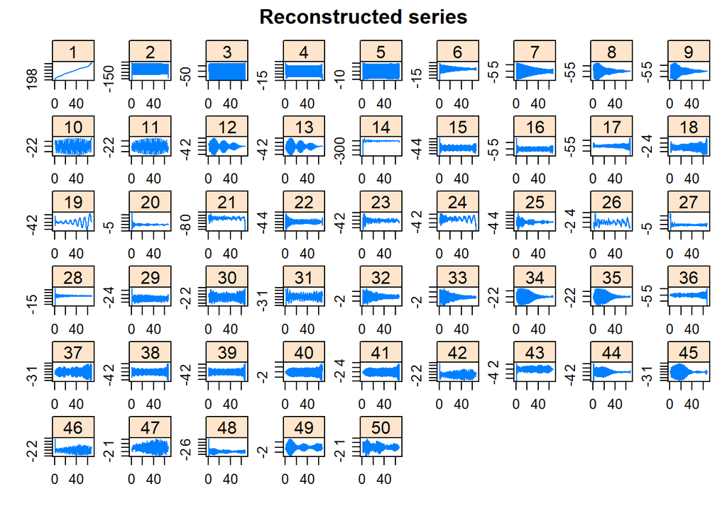

```r
plot(s,type="series")
```

К тренду отнесем первую компоненту.

Посмотрим на матрицу корреляций:

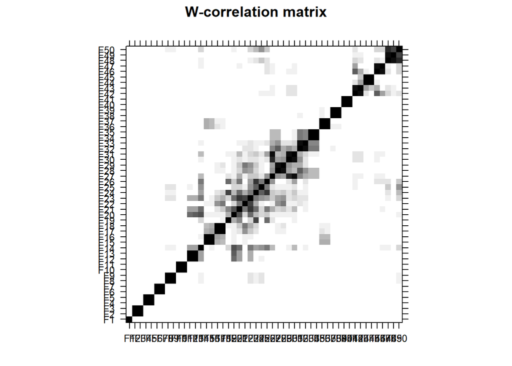

```r
cor <- wcor(s)
plot(cor)
```

Можно видеть, что первая компонента отделяется хорошо от других.

Посмотрим на выделенный нами тренд:

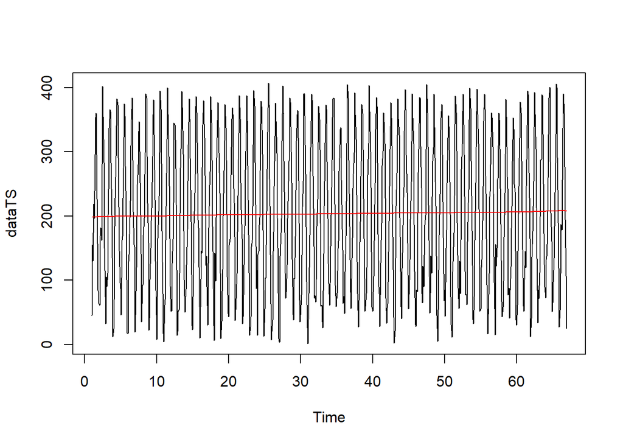

```r
rec <- reconstruct(s, groups = list(c(1)))
trend <- rec$F1
plot(dataTS, type = "l")
lines(trend, col = "red")
```

## Остаток после выделения тренда

Остаток это сезонность и шум. Глянем на периодограмму остатка:

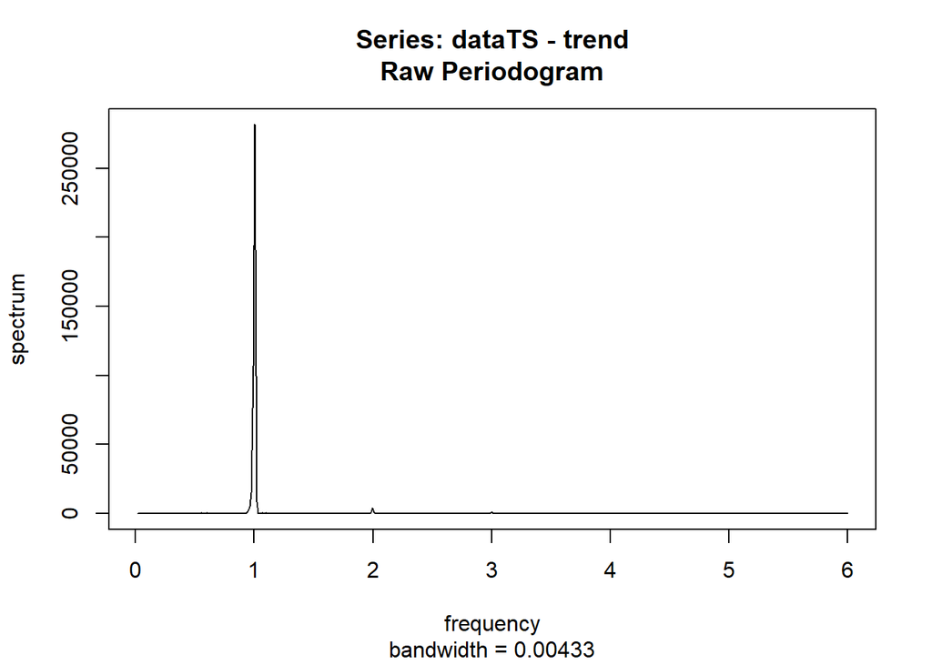

```r
spec.pgram(dataTS-trend,log="no")
```

Можно сказать, что ничего не изменилось.

Применяем второй раз SSa с меньшей длиной окна:

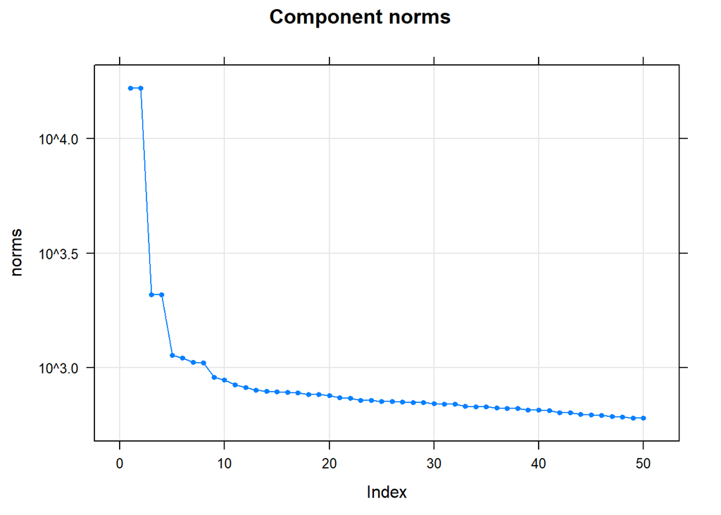

```r
season <- dataTS-trend
sseason <- ssa(season, L = 60)
plot(sseason)
```

Снова смотрим все графики

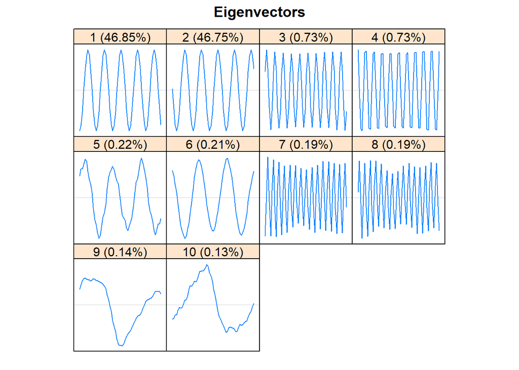

```r
plot(sseason, type = "vectors")
```

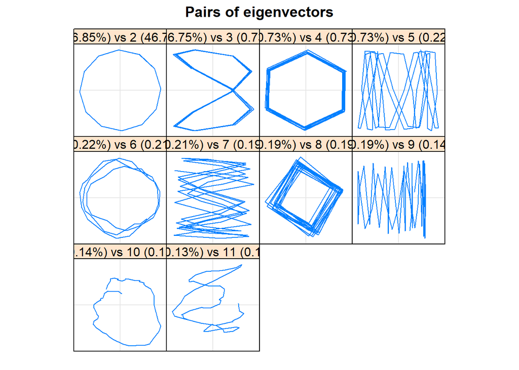

```r
plot(sseason, type = "paired",idx=1:10)
```

По этому графику к сезонности можно отнести период 12 (пара 1-2), период 6 (пара 3-4) и период 4 (пара 7-8)

Матрица корреляций:

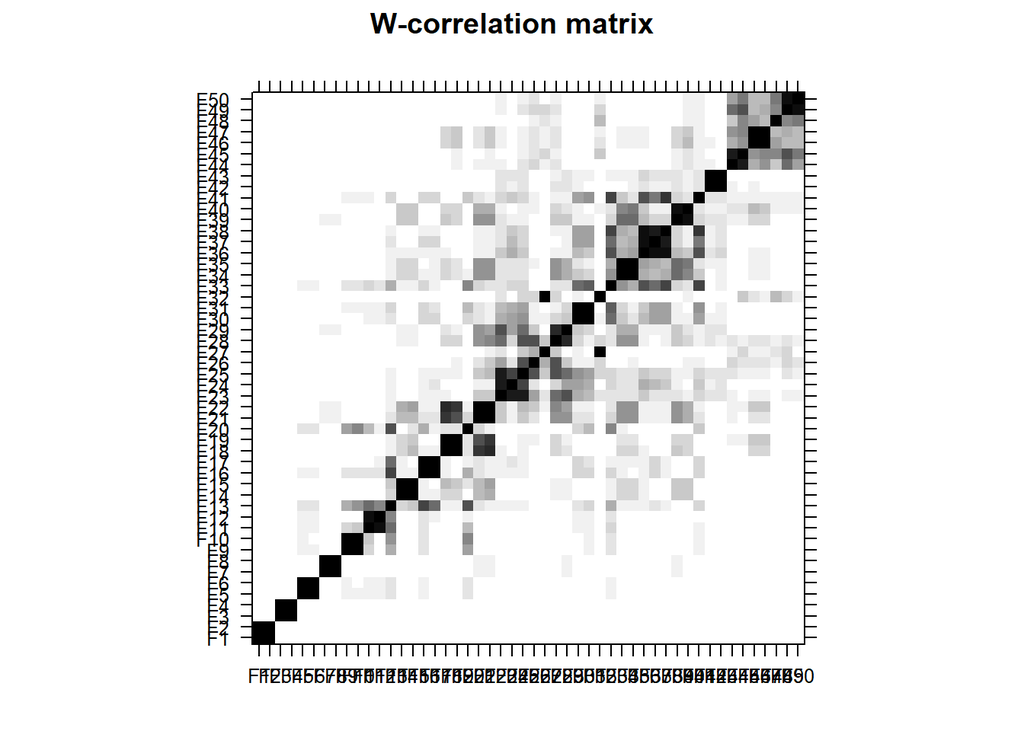

```r
plot(wcor(sseason))
```

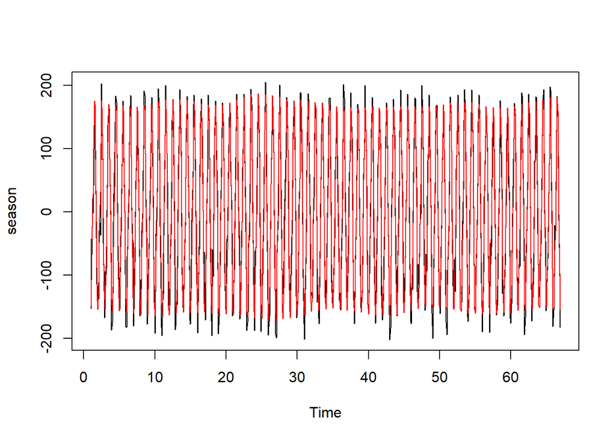

```r
recSeason <- reconstruct(sseason, groups = list(c(1,2,3,4,7,8)))
trendSeason <- recSeason$F1
plot(season,type='l')
lines(trendSeason,type='l',col='red')
```

Получим шум:

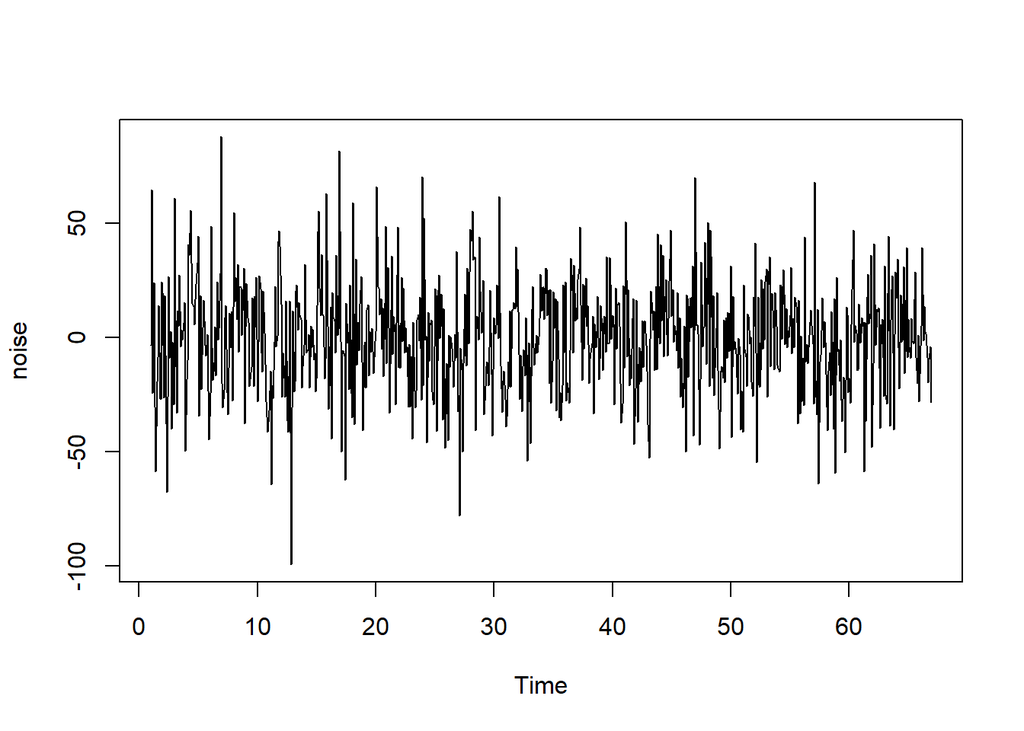

```r
noise <- season-trendSeason
plot(noise,type='l')
```

Периодограмма:

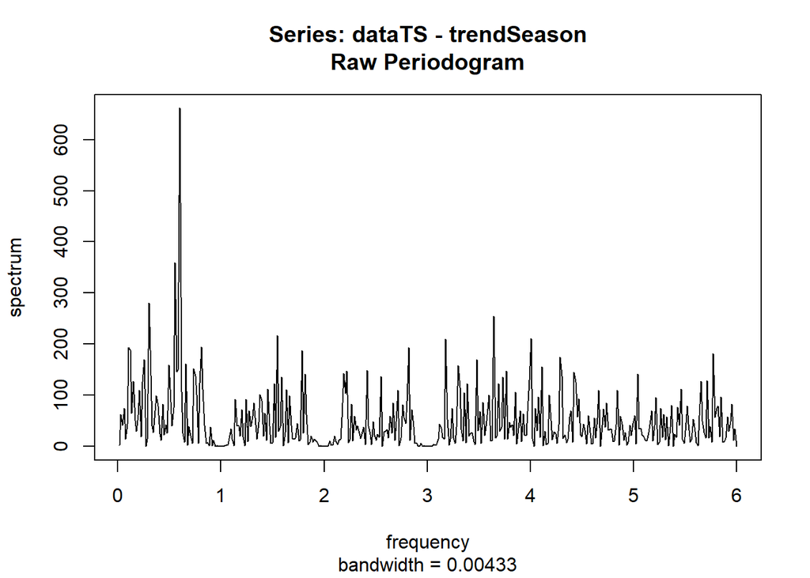

```r
spec.pgram(dataTS-trendSeason,log="no")
```

По периодограмме видно, что вырезаны куски. Посмотрим на график автокорреляций:

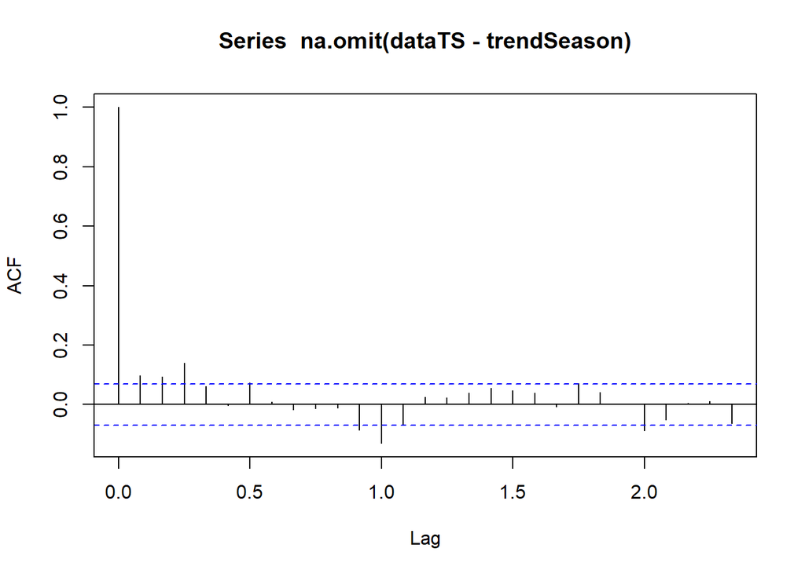

```r
acf(na.omit(dataTS-trendSeason))
```

Не белый шум явно. И результат получился хуже, чем при непоследовательном SSA.

Получили, что в нашем ряде нет смысла применять последовательный SSA.

# Огибающие для шума

Построим огибающие для шума при непоследовательном SSA:

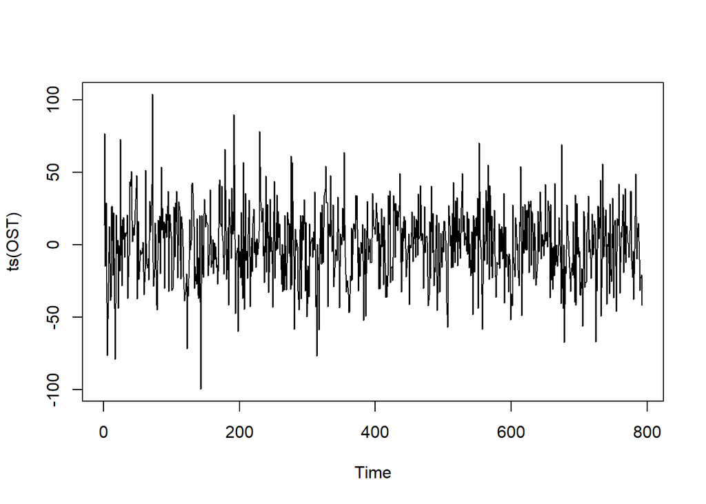

```r
plot(ts(OST))
```

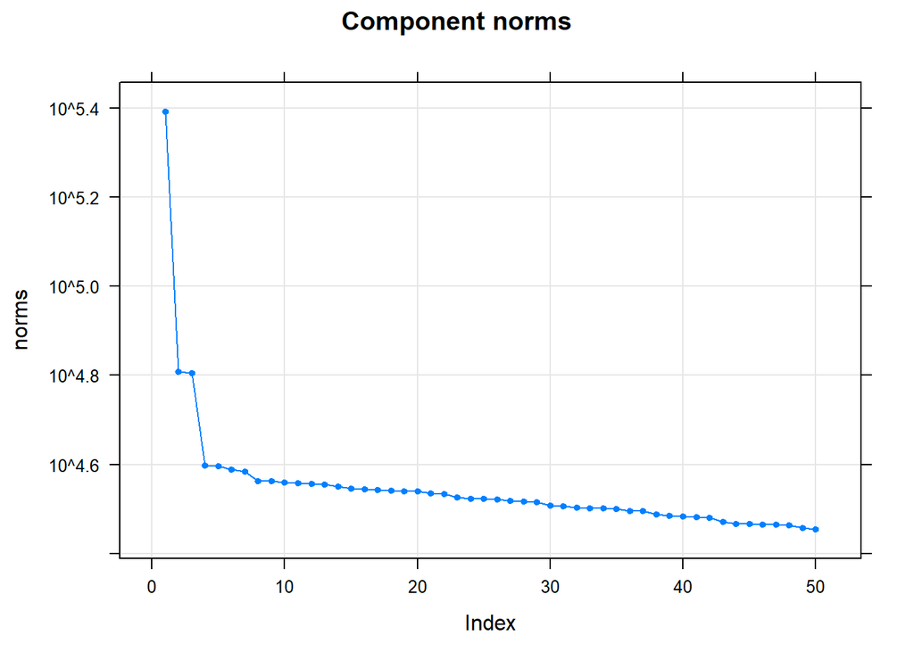

```r
sOST <- ssa(OST^2)
plot(sOST)
```

```r
plot(s, type="vectors")
```

[output not shown]

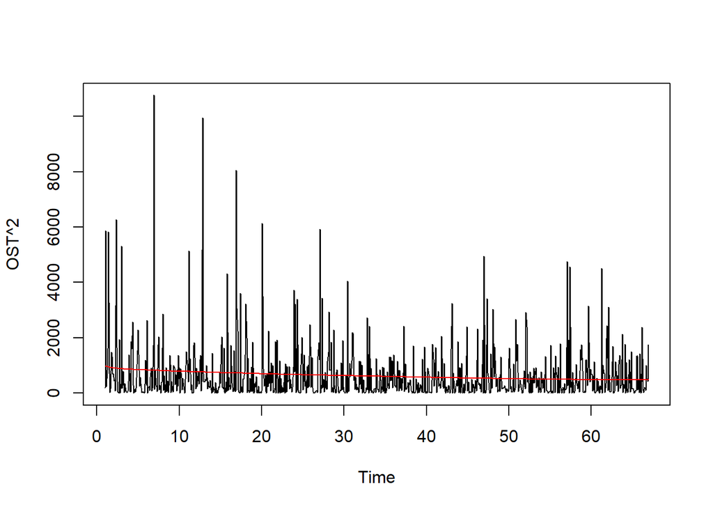

```r
recOST <- reconstruct(sOST,group=list(trend=c(1)))
plot(OST^2)
lines(recOST$trend, col="red")
```

Итак:

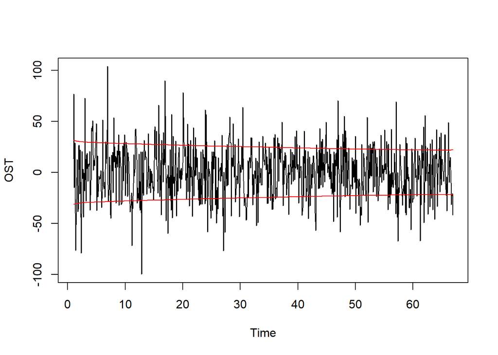

```r
plot(OST)
lines(sqrt(recOST$trend), col="red")
lines(-sqrt(recOST$trend), col="red")
```

# Огибающие для гармоники

На занятии было: как найти огибающую A(n)?

$x_n = A(n)cos(2\pi wn+\phi)$

$y_n=2x_n^2=A^2(n)+A^2(n)cos(2(2\pi wn+\phi))$ — первое слагаемое можно рассмотреть как тренд, второе — моделируемый косинус.

Рассмотрим это на примере выделенной периодичности при непоследовательном SSA:

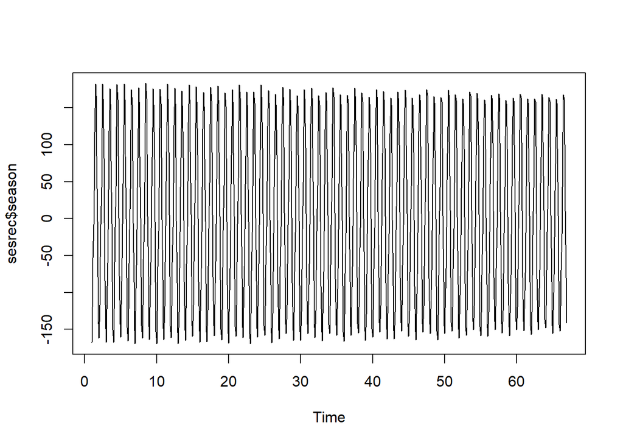

```r
plot.ts(sesrec$season)
```

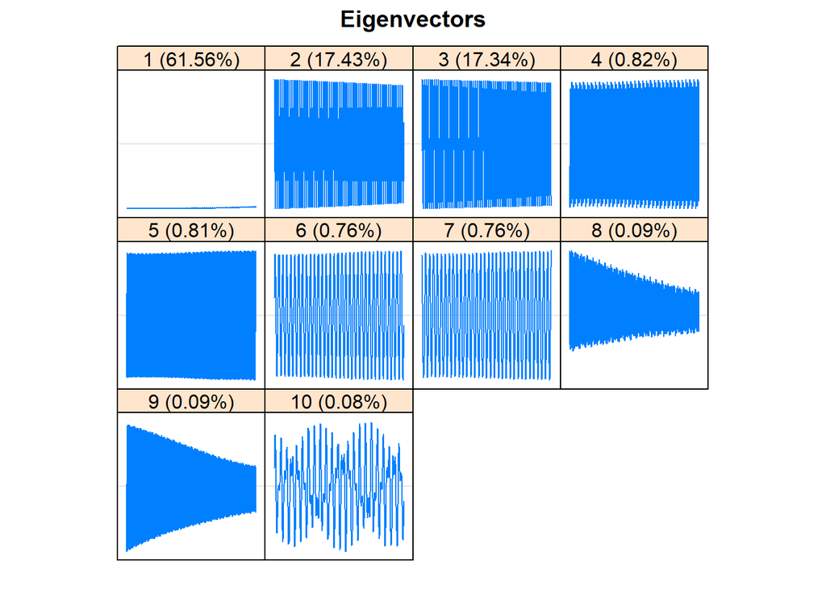

```r
#пусть y_n = 2*x_n^2
y_n <- 2*(sesrec$season^2)
sy_n <- ssa(y_n)
plot(sy_n, type="vectors")
```

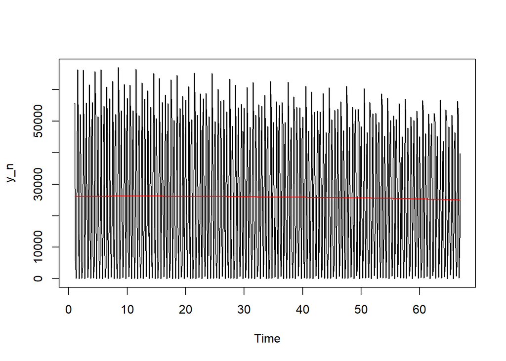

```r
recy_n <- reconstruct(sy_n, groups = list(trend=c(1)))
plot(y_n)
lines(recy_n$trend, col="red")
```

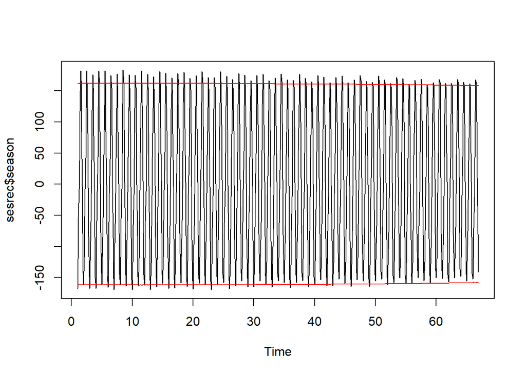

```r
plot(sesrec$season)
lines(sqrt(recy_n$trend), col="red")
lines(-sqrt(recy_n$trend), col="red")
```

Получили огибающие для гармоники.